# 意大利新冠肺炎疫情预测及理性评估

戎翔 高彦梅 李宇 卫晓帆

2020/6/24

# 1引言

## 1.1背景及研究内容

2019年12月，我国湖北省武汉市陆续出现多起不明原因的病毒性肺炎，一种新发现的冠状病毒随即被确认为导致武汉不明原因肺炎病例的病原体。2020年1月12日，世界卫生组织将该病毒命名为“2019新型冠状病毒(2019-nCoV)”，同年2月11日，国际病毒分类委员会又将其正式更名为严重急性呼吸综合征冠状病毒2(SARS-Cov-2)，世界卫生组织于同日该病毒导致的疾病正式命名为2019新型冠状病毒疾病(COVID-19)，国家卫健委随后将新型冠状病毒肺炎的英文缩写标准化为COVID-19。COVID-19传染性极强，迅速从武汉蔓延至全国各地，并在境外多个国家和地区传播，波及全球200多个国家。

根据最新数据统计，全球新冠肺炎累计确诊病例数突破731万例。目前，全球有8个国家累计确诊数超过20万，其中，美国累计确诊病例已经突破204万例，意大利、巴西等7个国家的累计确诊病例最新突破20万。此次新冠肺炎疫情给全世界带来了前所未有的挑战，其后续影响难以估量。意大利作为世界旅游业较发达的国家之一，也不可避免地受到了严重的影响。这种影响不仅发生于意大利与其他国家之间，更发生于意大利国内的方方面面。 因此，本文分别利用指数平滑以及ARIMA模型对意大利新冠肺炎情况进行了预测分析，并利用灰色系统分析方法具体定量分析新冠肺炎对2020年意大利旅游收入产生的损失。

## 1.2文献综述

林硕蕾利用灰色系统理论建立GM（1,1）模型，由1997-2002年旅游外汇收入的平均值预测2003年旅游外汇收入平均值；并通过历史数据计算每个月的指标值与全年总值的关系，得出每个月旅游外汇收入所占全年旅游收入的权重，从而预测出正常情况下2003年每个月外汇旅游收入的指标值；最后将其与2003年每月外汇旅游收入的真实值进行比较，定量分析SARS对旅游外汇收入的影响[1]。

王旭艳等人利用1月23日到3月25日湖北省疫情数据，采用平滑指数模型对湖北省新冠肺炎疫情变化趋势进行分析和预测。结果表明，采用指数平滑模型获得的拟合值与实际值的趋势基本吻合，模型拟合效果较好，预测结果表明在4月2日现存确诊病例数将减少至1000例以内，且主要为重症和危重症病例[2]。

严婧，杨北方对湖北省丙肝疫情资料进行整理，将2004年1月－2014年12月丙肝发病数据作为建模部分，2015年1－12月发病数据作为模型验证分部，对丙肝不同年份发病率进行趋势卡方检验，建立 ARIMA模型和指数平滑法，并进行模型的参数估计、拟合检验、计算和预测、检验与评价。将预测值与实际值进行比较，计算相对误差绝对值，相对误差绝对值越小说明预测越准确，然后进行型预测效果比较[3]。

# 2数据来源及描述统计

## 2.1数据来源

疫情数据来源于世界卫生组织官网(https://www.who.int/)，选取意大利3月1日-6月7日的数据，具体包括累计确诊人数、新增确诊人数、累计治愈、新增治愈人数、累计死亡人数以及新增死亡人数。根据每日疫情数据，可以依据累计确诊人数、累计死亡人数以及累计治愈人数求得现存确诊人数，以及移除人数，其中现存确诊人数=累计确诊人数-累计死亡人数-累计治愈人数，移除人数=累计死亡人数+累计治愈人数。

有关意大利旅游收入的数据来源于(https://zh.tradingeconomics.com/)。为了避免2008年金融危机对本次分析产生影响，我们选取2009年-2020年的数据。

## 2.2意大利疫情基本描述

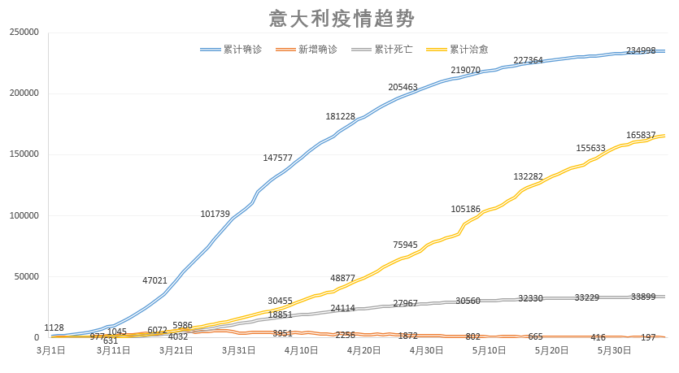

截至6月7日，意大利累计确诊人数达23万之多，累计病例数从3月初开始迅速增加，到5月份左右减缓，而后趋于稳定，尤其在近日以来，新增确诊病例数在200左右波动，并且在不断减少，说明意大利疫情得到了较好的控制。

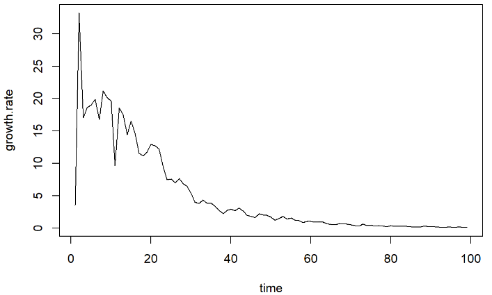

随着新增确诊人数的先增后减，增长率曲线也呈现出先增后减的趋势，在3月1日-3月22日期间，增长率大于10%，而后逐渐减小，在4月29日以后增长率均小于1%，并逐渐趋向于0，说明意大利的COVID-19得到了有效控制。

## 2.3疫情下的意大利旅游经济

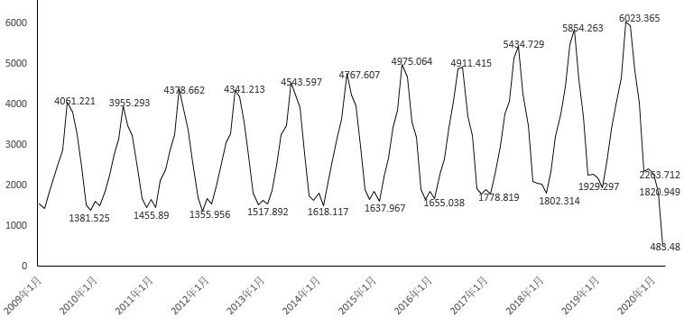

意大利2009-2020年的旅游收入走势图显示，旅游收入逐年上升，并呈规律性的周期变化，在每年7月份左右旅游收入最高，1月份左右最低。由于COVID-19的影响，意大利2020年的旅游收入在一月份下滑后并没有回升，甚至在3月份降到了483.48百万欧元，降到了近十年的最低点，可见COVID-19疫情对意大利经济有着不容忽视的影响。

# 3指数平滑法

# 4基于arima模型对意大利新冠肺炎死亡人数的预测

## 4.1方法介绍

ARIMA模型即自回归移动平均模型，时间序列分析模型通常是指求和自回归移动平均模型(Autoregressiveintegratedmovingaverage，ARIMA)，由统计学家Box和Jenkins于1970年首次系统提出，以数理统计和微积分等传统数学理论为基础建立起来的预测模型，是时间序列分析方法中应用比较广泛的方法之一，短期预测准确率较高。在病预测等方面得到广泛应用。根据序列特征，可分为平稳和非平稳时间序列。对于非平稳时间序列，可以通过d次差分运算将其转换为平稳时间序列，此时即为ARIMA。ARIMA模型的形式可表示为ARIMA(p,d,q)。p,d,q分别表示自回归阶数、差分阶数和移动平均阶数。模型构建过程包括数据时间序列平稳化、模型识别、参数估计和模型检验。本研究收集今年3月1号到6月7号意大利疫情数据，用ARIMA模型对死亡人数进行模型构建、拟合，并应用最优模型参数预测意大利疫情发展趋势，以期发现意大利疫情的潜在变化规律，为开展防控工作提供理论依据。

## 4.2 ARIMA模型的建立

### (1)平稳性和白噪声（White noise）检验

ARIMA建模要求序列为平稳且是非随机性序列，若数据为非平稳时间序列，则可对原序列进行差分运算使其转换为平稳序列。白噪声检验，也称为纯随机性检验，主要用来检验数据是否为纯随机序列。本研究主要用单位根ADF的方法进行平稳性检验；计算LB统计量进行白噪声检验。

### (2)模型识别和定阶

对平稳非白噪声差分序列，依据自相关图（ACF）和偏自相关图（PACF）初步选择合适的模型参数进行拟合。模型定阶根据最小信息量原则（Akaikeinformationcriterion，AIC）和贝叶斯信息准则（Bayesia information criterion，BIC）进行，AIC和BIC值最小的模型为最佳。

### (3)参数估计与模型检验

在模型识别阶段，采用最大似然法对粗模型进行参数估计与显著性检验。模型显著性检验即残差白噪声检验，是检验模型是否充分提取了序列信息，即残差是否为白噪声。若是，则构建的模型可以用于预测；否则，返回第2步重新。

### (4)模型预测

建立3月1号到6月7号意大利新冠肺炎死亡人数变化模型进行预测

## 4.3统计分析

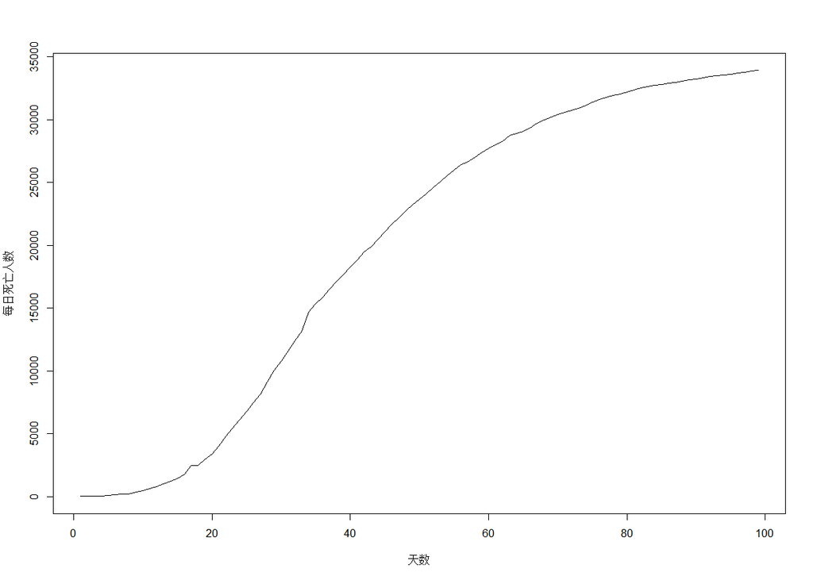

意大利3月1号到6月7死亡人数数据绘制时间序列图，可见明显的递增趋势，长期而言呈递增速度在减慢，为不平稳序列，因此对其2阶差分以使其平稳.

尽管有文献提及肺炎发病具有季节性，但就此次而言，由于是新型肺炎，之前未发生过，数据也少，故不宜进行季节性差分。根据ndiffs函数可知原为二阶后平稳。经处理后，原始数据趋于平滑，对数据进行处理后的自相关函数（ACF）分析图与偏自相关函数（PACF）分析图，如下图所示.

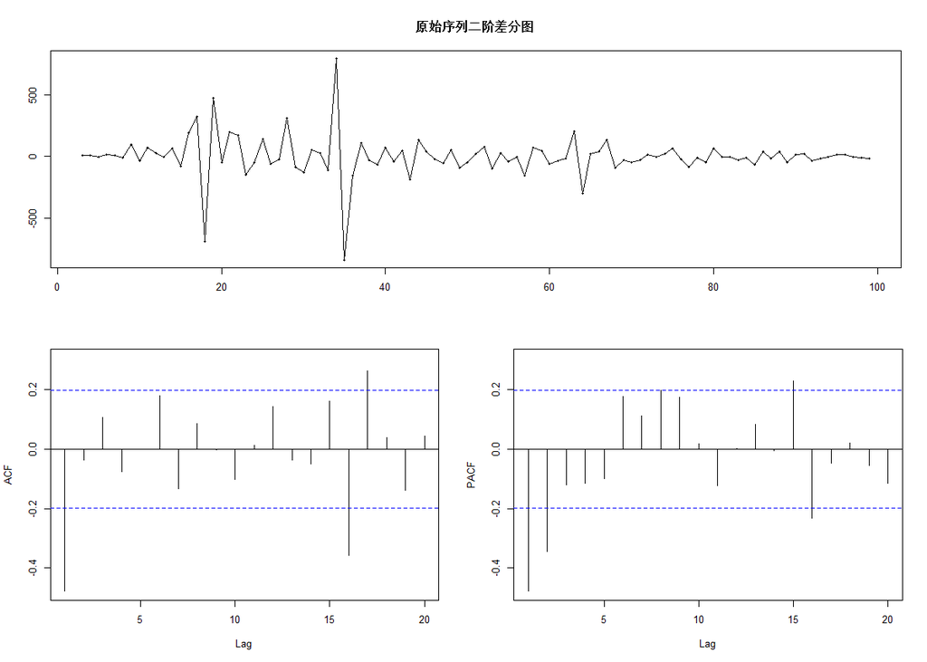

经过ADF单位根检验，P值小于0.01，显示原始序列二阶差分后为平稳序列。经过白噪声检验，P值小于0.01，证明原始序列二阶差分后不是白噪声序列，即序列中包括有意义的数据，继续拟合模型。由acf图和pacf图以及auto.arima函数，可尝试拟合ARIMA(0,2,1)。ARIMA（2，2，0），ARIMA（1，2，2）

ARIMA（2，2，0）的系数与标准误相除，绝对值均大于1.96，系数是显著的，残差通过白噪声检验， aic = 1242.48 bic=1250.2。

ARIMA（1，2，2）虽然系数显著，但是模型不可逆，舍去.AIC=1236.23, BIC=1246.53

ARIMA（0，2，1）系数显著.残差也通过白噪声检验.aic = 1240.92 ， bic=1246.069经过比较，最终选择ARIMA(0,2,1)。

## 4.4模型预测与应用

应用该预测模型对第100天（6月8号）到第108天（6月16号）进行预测，其预测值分别为：33966，34034，34101，34169，34236，34303，34371，34438，34506.

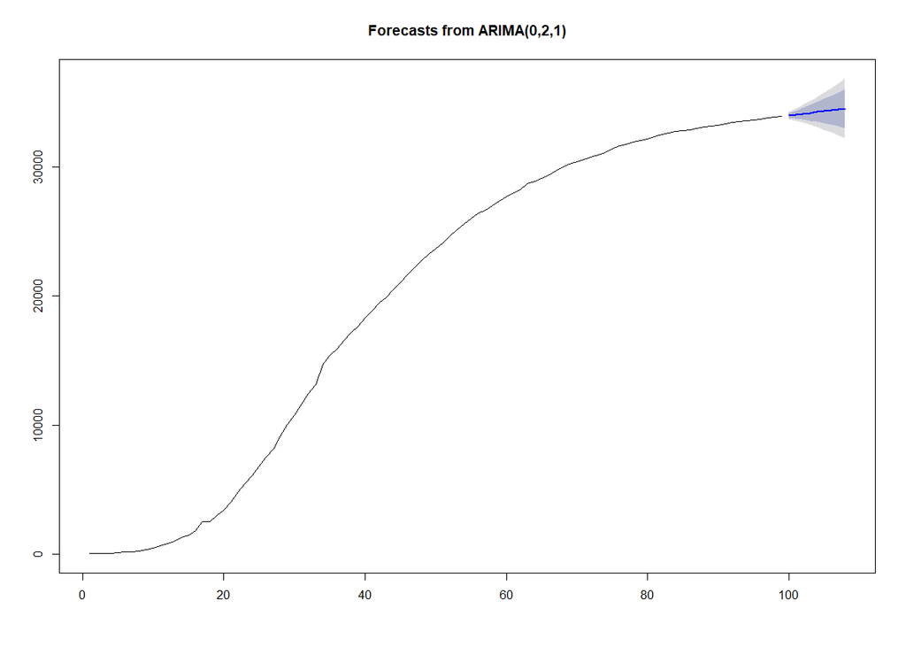

# 5基于灰色系统GM（1,1）模型分析2019-nCoV对意大利旅游经济的影响

## 5.1模型介绍

灰色模型（GreyModel，简称GM），即通过累加、累减等方式把原始数据变换成生成序列，再利用其中的规律进行建模预测的方法，可针对不同问题建立相应的灰色模型，如GM(1,1)，GM(1,m)，GM(n,m)，分别用于一个自变量一个因变量，多个自变量一个因变量，多个自变量多个因变量。模型的优点是可以利用较少的数据进行预测，通过微分方程充分挖掘系统的本质，精度较高，可适用于中短期的预测。

其中，GM（1,1）模型是灰色系统理论中的基本模型，它将无规律的原始数据累加生成后, 使其变为有规律的生成数列，然后建立相应的微分方程模型，从而预测事物未来发展趋势和状态。

根据我们收集的历史数据可以看出，在正常情况下，全年的平均值能较好地反映出意大利旅游收入的变化规律，据此把预测分成两部分：

(1)利用灰色理论建立 GM（1,1）模型，由2009- 2019年的平均值预测 2020年平均值；

(2)通过历史数据计算每个月的旅游收入与全年总值的关系，从而预测出正常情况下 2020年每个月的旅游收入。

## 5.2 GM（1,1）建模步骤：

### ①数据的检验与处理

根据收集的数据计算出2009-2019年意大利旅游收入的平均值，即模型的原始数据列，记为$x^{(0)}=(x^{(0)}(1),x^{(0)}(2),...,x^{(0)}(n))$,计算数列的级比：
$$\lambda={x^{(0)}(k-1)}/{x^{(0)}(k)},k=2,3,...,n$$

若所有级比都落在可容覆盖区间$x=(e^{{-2}/{n+1}},e^{{2}/{n+1}})$内，则数列可建立GM（1,1）模型。否则，需要对数据做适当的变换处理，如平移变换$y^{(0)}(k)=x^{(0)}(k)+c,k=1,2,...,n$，取c使得数据列的级比都落在可容覆盖区间(0.846,1.181)内，因此可以建立GM（1,1）模型。

### ②累加生成

令$x^{(1)}$为$x^{(0)}$的一次累加序列，则$x^{(1)}=(x^{(1)}(1),x^{(1)}(2),...,x^{(1)}(n))$，其中，$x^{(1)}(k)=\sum_{i=1}^{k}{x^{(0)}(i)},k=1,2,...,n$。

### ③均值生成

令$z^{(1)}$为$x^{(1)}$的紧邻均值生成序列，$z^{(1)}=(z^{(1)}(1),z^{(1)}(2),...,z^{(1)}(n))$，其中，$z^{(1)}(k)=1/2(x^{(1)}(k)+x^{(1)}(k+1)),k=1,2,...,n$.

### ④GM（1,1）模型

GM（1,1）模型的灰微分方程为：$x^{(0)}(k)+az^{(1)}(k)=b$。式中，a为发展系数，b为灰作用量，均为待定系数。

设待估参数向量$\hat{a}=[\hat{a},\hat{b}]^T$，则灰微分方程的最小二乘估计参数列满足$\hat{a}=[\hat{a},\hat{b}]^T=(B^TB)^{-1}B^TY$,其中，
$$B=\left[ \begin{matrix} -z^{(1)}(2) &1\\-z^{(1)}(3) &1\\ \vdots &\vdots\\-z^{(1)}(n) &1\end{matrix} \right]$$
$$Y=\left[ \begin{matrix} x^{(0)}(2) \\x^{(0)}(3) \\ \vdots \\x^{(0)}(n) \end{matrix} \right]$$

则此模型的时间响应函数为$x^{(1)}(t)=(x^{(1)}(1)-\frac {b} {a}){\rm e}^{-at}+\frac {b} {a}$,估计出参数a、b以后，可以利用此函数对原始序列进行预测。

### ⑤模型检验

在利用GM（1,1）模型进行预测前，需要进行模型精度和误差的检验，来保证预测的准确性。

#### ⑴残差检验

对估计值和实际值的残差进行逐点检验，并计算原始序列$x^{(0)}(i)$与$\hat{x}^{(0)}(i)$的绝对残差序列$\Delta^{(0)}(i)=|x^{(0)}(i)-\hat{x}^{(0)}(i)|$，进而计算其相对残差序列$\phi_i=\frac {\Delta^{(0)}(i)} {x^{(0)}(i)}$，最后得出整个模型的平均相对误差$\bar{\phi}=\frac{1}{n}\sum_{i=1}^{n}{\phi_i}$，将其与给定的残差水平进行比较，若小于给定的残差水平，则称模型为残差合格模型。

### ⑥预测

根据历史数据计算出2020年每个月的旅游收入占全年总值的比例$u_i$，即$u_i=\sum_{j=1}^{11} {a_{ij}}/\sum_{i=1}^{12} {\sum_{j=1}^{11} {a_{ij}}}$，在得到2020年的预测值后，可算出2020年每个月的旅游收入预测值。

## 5.3模型求解

从而得到其紧邻均值生成序列：
$$Z^{(1)}=(3623.75,6129.90,8752.67,11467.23,14272.82,17181.00,20177.46,23323.88,266693.34,30277.28,32123.21)$$

求得其发展系数和灰作用量：$a=-0.0445,b=2251.087$，则此模型的时间响应函数为
$$x^{(1)}(t)=52990.92{\rm e}^{0.0445t}-50586.22$$

在利用上式进行预测之前，对其模型精度和误差进行检验。在软件中计算得到，残差检验中$\phi=0.0155$，在0.01与0.05之间，模型精度合格；而在后验差检验中，$C=0.0898$，小于0.35，模型精度为优。因此，可以用此模型对2020年意大利月均旅游收入进行预测。

根据上式预测得到：$X^{(0)}(11)=3763.723(百万）$,即预测所得2020年全年旅游收入为45164.68（百万）。预测结果如图1所示。

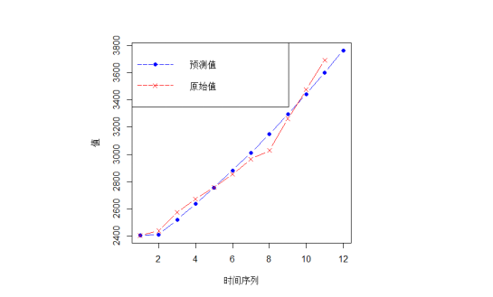

同时，2020年第i个月的指标值占全年总值的比例为
$$u=(0.0511,0.0459,0.0606,0.0759,0.0934,0.1056,0.1363,0.1313,0.1095,0.0868,0.0539,0.0496)$$
月度预测值与月度真实值比较结果见表2。

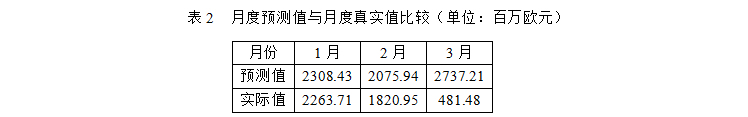

## 5.4结果分析

# 6总结

模型对死亡人数的分析表明，新冠肺炎死亡人数的增长率正日益交降低，趋于平稳。从一开始的指数增长到平稳发展经历了一百天左右的过程，说明意大利现行的疫情政策非常有效果。结合具体预测数据，有理由相信意大利新冠疫情会在最近得到较为充分的控制。

此次疫情除了对意大利造成了严重的人员伤亡外，也对当地的旅游经济产生了很大的冲击，这种冲击在三月份达到了最大，三月份的旅游收入低落到近十年的最低点，这对意大利旅游经济造成了巨大的冲击。但随着疫情的逐渐控制以及当地政府经济政策的实施，相信意大利经济会有所好转。

综上所述，意大利新冠肺炎疫情情况的改善与政策的实施有密不可分的关系，早在3月10日，意大利便开始实行封锁政策，成为欧洲第一个封国的国家。随着全球疫情不断蔓延，意大利疫情却开始呈现下降趋势，可见，在强有力的政策管控下，意大利新冠肺炎疫情情况得到好转，从最开始的累计确诊人数排名第二到目前的排名第七。因此，在其他地区疫情较为严重且本国尚存在新增确诊病例的情况下，防疫意识不可松懈，仍应该保持警惕，注重个人卫生，在重振经济的同时继续做好防疫工作，尽快取得真正的解放。

# 参考文献

[1]林硕蕾.灰色系统在经济上的应用-定量分析SARS对旅游外汇收入的影响 [2]王旭艳,喻勇,胡樱,宇传华.基于指数平滑模型的湖北省新冠肺炎疫情预测分析[J].公共卫生与预防医学,2020,31(01):1-4. [3]严婧，杨北方.指数平滑法与ARIMA模型在湖北省丙型病毒性肝炎发病预测中的应用 [4]张文斗,祖正虎,许晴,徐致靖,郑涛.SARS疫情对中国交通运输业和电信业的影响分析[J].军事医学,2012,36(10):762-764+800. [5]林硕蕾,王凌冉.灰色系统在经济上的应用——定量分析SARS对旅游外汇收入的影响[J].北京工业职业技术学院学报,2005(04):81-83+87. [6]张世强,张飒岚,蒋峥,王春丽,王婷. 基于信息挖掘的麻疹流行趋势GM(1,1)评价模型[C]. 中国电子学会信息论分会.Proceedings of 2010 Asia-Pacific Conference on Information Theory (APCIT 2010).中国电子学会信息论分会:中国电子学会信息论分会,2010:335-338. [7]金启轩.中国新冠肺炎疫情预测建模与理性评估[J].统计与决策,2020,36(05):11-14.